# Assignment 4

Mary Anna Kivenson

2/25/2019

## Importing Data

Import a .csv file that uses a “wide” structure (see below). We will tidy and transform this data.

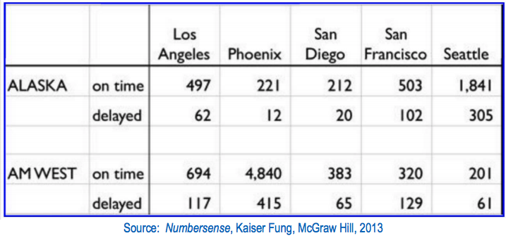

```r
raw <- read.csv("https://raw.githubusercontent.com/mkivenson/Data-Acquisition-and-Management/master/Assignment%204/airlines.csv", na.strings="")
raw
```

```
##         X     X.1 Los.Angeles Phoenix San.Diego San.Francisco Seattle
## 1  ALASKA on time         497     221       212           503    1841
## 2    <NA> delayed          62      12        20           102     305
## 3    <NA>    <NA>          NA      NA        NA            NA      NA
## 4 AM WEST on time         694    4840       383           320     201
## 5    <NA> delayed         117     415        65           129      61
```

## Tidying and Transforming

Using the dplyr and zoo libraries, we tidy this data so that:

#### Columns for different cities become one column

```r
flights <- (gather(raw,"city","count","Los.Angeles","Phoenix","San.Diego","San.Francisco","Seattle"))
```

#### All columns have column names

```r
colnames(flights) <- c('airline','status','city','count')
```

#### All rows are populated with airline information

```r
flights <- flights %>% do(na.locf(flights))
```

#### All rows are distinct

```r
flights <- flights %>% distinct()
```

This gives us the tidy data table you see below.

```r
datatable(flights)
```

|  | airline | status | city | count |
| --- | --- | --- | --- | --- |
| 1 | ALASKA | on time | Los.Angeles | 497 |
| 2 | ALASKA | delayed | Los.Angeles | 62 |
| 3 | AM WEST | on time | Los.Angeles | 694 |
| 4 | AM WEST | delayed | Los.Angeles | 117 |
| 5 | ALASKA | on time | Phoenix | 221 |
| 6 | ALASKA | delayed | Phoenix | 12 |
| 7 | AM WEST | on time | Phoenix | 4840 |
| 8 | AM WEST | delayed | Phoenix | 415 |
| 9 | ALASKA | on time | San.Diego | 212 |
| 10 | ALASKA | delayed | San.Diego | 20 |

[output cut: 10 more lines]

## Analysis of Arrival Delays

#### How often do flights get delayed at each airport, airline, and city? How often are they on time?

With three categorical variables and one numerical variable, it may be challenging to create a visual that depicts all three. First, I created a facet grid showing the count of occurances of each combination of categorical variables (airline, city, and delay status). Observe that AM West flights at Phoenix and Alaska flights at Seattle seem to be on time the most.

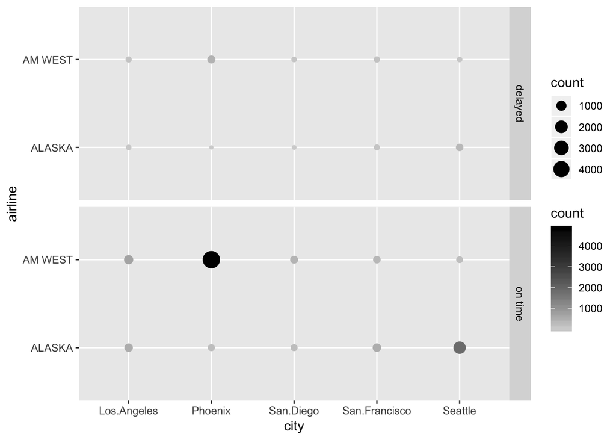

```r
ggplot(flights, aes(city, airline, size = count, color = count)) + geom_point() + facet_grid(rows = vars(status))   + scale_color_gradient(low="light grey", high="black")
```

#### What is the probability of a flight that is delayed or on time?

In the previous chart, we see that AM West at Phoenix has the most on time flights - however the same airline at the same city also has more delays than any other city for that airline. It is likely that Phoenix just has a more AM West and Alaska flights. This information is not very useful in determining how punctual flights at a certain airline or city are. Instead, we use dplyr to turn the counts into a proportion of delayed and on time flights for each combination of city and airline.

```r
flightsprop <- flights %>%
group_by(city, airline, status) %>%
  summarise (count) %>%
  mutate(freq = count / sum(count))

datatable(flightsprop)
```

|  | city | airline | status | count | freq |
| --- | --- | --- | --- | --- | --- |
| 1 | Los.Angeles | ALASKA | delayed | 62 | 0.110912343470483 |
| 2 | Los.Angeles | ALASKA | on time | 497 | 0.889087656529517 |
| 3 | Los.Angeles | AM WEST | delayed | 117 | 0.144266337854501 |
| 4 | Los.Angeles | AM WEST | on time | 694 | 0.855733662145499 |
| 5 | Phoenix | ALASKA | delayed | 12 | 0.0515021459227468 |
| 6 | Phoenix | ALASKA | on time | 221 | 0.948497854077253 |
| 7 | Phoenix | AM WEST | delayed | 415 | 0.0789724072312084 |
| 8 | Phoenix | AM WEST | on time | 4840 | 0.921027592768792 |
| 9 | San.Diego | ALASKA | delayed | 20 | 0.0862068965517241 |
| 10 | San.Diego | ALASKA | on time | 212 | 0.913793103448276 |

[output cut: 10 more lines]

#### Which airlines and cities have the most reliable flights?

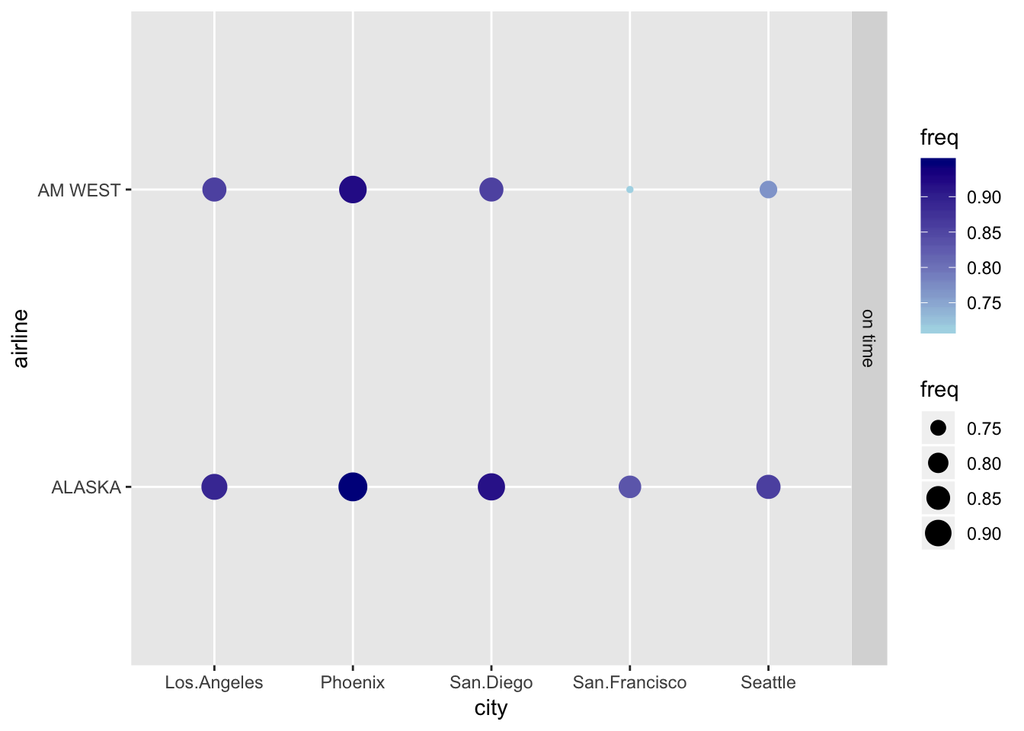

```r
flightsprop_ontime <- subset(flightsprop, status == 'on time')
ggplot(flightsprop_ontime, aes(city, airline, size = freq, color = freq)) + geom_point() + facet_grid(rows = vars(status))  + scale_color_gradient(low="light blue", high="dark blue")
```

#### Which airlines and cities have the least reliable flights?

We create a similar table to the one above, except this facet grid shows the proportions of delayed flights for each airline and city. Although it is slightly redundant, it is helpful to review the inverse grid. We see that AM West at San Francisco is the least reliable airline/city combination, followed by AM West at Seattle.

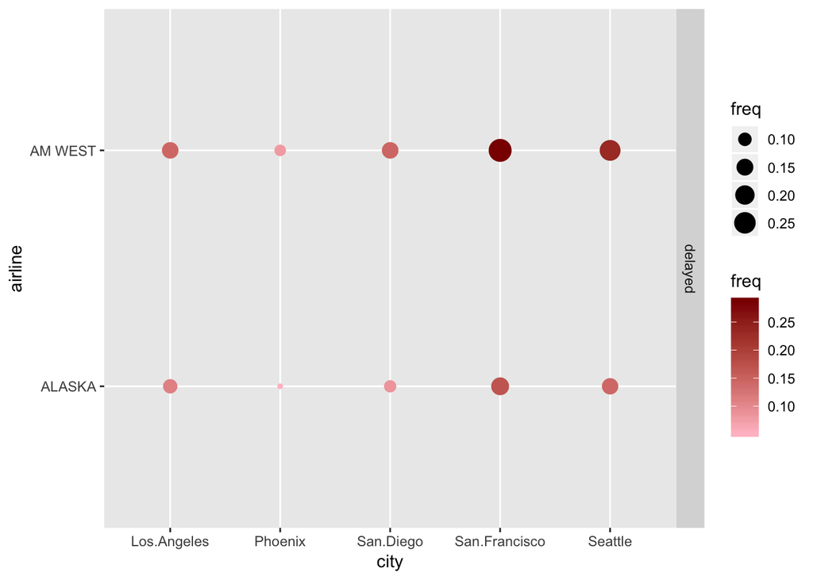

```r
flightsprop_delay <- subset(flightsprop, status == 'delayed')
ggplot(flightsprop_delay, aes(city, airline, size = freq, color = freq)) + geom_point() + facet_grid(rows = vars(status))  + scale_color_gradient(low="pink", high="dark red")
```